# FigureYa64triangle

**Author(s)**: Yin Li  
**Reviewer(s)**: Ying Ge, Yijing Chen  
**Date**: 2025-11-24

## 1 Academic Citation

If you use this code in your work or research, we kindly request that you cite our publication:

Xiaofan Lu, et al. (2025). FigureYa: A Standardized Visualization Framework for Enhancing Biomedical Data Interpretation and Research Efficiency. iMetaMed. https://doi.org/10.1002/imm3.70005

To cite ggtern in publications use:

Hamilton NE and Ferry M (2018). ggtern: Ternary Diagrams Using ggplot2. Journal of Statistical Software, Code Snippets, 87(3), pp. 1-17. doi: 10.18637/jss.v087.c03

## 2 需求描述 Requirement Description

用R画出paper里的Triangle plot

Use R to draw the Triangle plot in the paper

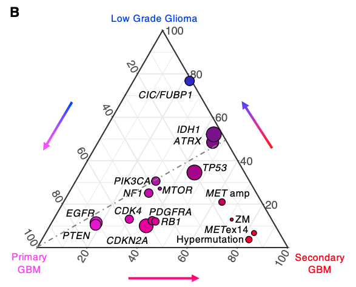

原文解析：

- 点的坐标代表其突变频率，越靠近三角形的一个角，代表在这个类型突变越多；
- 点的大小代表在glioma这个病中，总共的突变频率；
- 颜色代表相对突变频率

From https://www.cell.com/cell/fulltext/S0092-8674(18)31250-9?_returnURL=https%3A%2F%2Flinkinghub.elsevier.com%2Fretrieve%2Fpii%2FS0092867418312509%3Fshowall%3Dtrue

Original analysis:

- The coordinates of the dots represent their mutation frequency, the closer to one corner of the triangle, the more mutations in this type;
- The size of the dots represents the total frequency of mutations in glioma;
- The color represents the relative mutation frequency

## 3 应用场景 Application Scenario

展示3种不同疾病或者3组之间某个指标的相关性，一目了然。

脑洞大开，发挥你的想象力，一定能拓展出更多应用场景。

Display the correlation of a certain indicator among 3 different diseases or 3 groups, clearly and concisely.

Use your imagination to develop more application scenarios.

## 4 环境设置 Environment Setting

```r
source("install_dependencies.R")
```

[output not shown]

```r
library(tidyverse) # 数据处理和转换 Data manipulation and transformation
library(scales) # 数据缩放 Data scaling
library(ggplot2) # 数据可视化 Data visualization
library(directlabels) # 直接标签 Direct labels
library(ggtern) # 三角图 Triangle plot

# 如果需要使用本地源码版本（用于调试或特定版本需求），可以取消下面的注释
# If you need to use local source code version (for debugging or specific version requirements), uncomment the following
# source("load_ggtern_local.R") # 从 GitHub 源码中提取的核心函数 Core functions extracted from GitHub source code

Sys.setenv(LANGUAGE = "en") #显示英文报错信息 display English error messages
options(stringsAsFactors = FALSE) #禁止chr转成factor prohibit the conversion of chr to factor
```

## 5 输入数据预处理 Preprocessing of input data

如果你的数据已经整理成“easy_input.csv”的格式，就可以跳过这步，直接进入“输入文件”。

下载原文的补充材料Table2.pdf，整理为”not_easy_input.csv”

If your data has been organized into “easy_input.csv” format, you can skip this step and go directly to “Input file”.

Download the original supplementary material Table2.pdf and organize it as “not_easy_input.csv”.

## 6 直接用原文数据画图 Draw a graph directly using the original data

```r
df <- read.csv("not_easy_input.csv")
head(df)
```

```
##            Gene Altered.in.sGBM Total.of.sGBM Frequency.in.sGBM
## 1       METex14              11            78              0.14
## 2 Hypermutation              23           145              0.16
## 3            ZM               4            78              0.05
## 4 MET Amplified              17           145              0.12
## 5          ATRX              59           145              0.41
## 6          TP53              99           145              0.68
##   sGBM.Specificity Altered.in.pGBM Total.of.pGBM Frequency.in.pGBM
## 1            11.03               3           174              0.02
## 2            10.72               5           190              0.03
## 3             6.02               2           174              0.01
## 4             3.43               8           273              0.03
## 5             1.66              14           273              0.05
## 6             1.66              82           273              0.30
##   Altered.in.LGG Total.of.LGG Frequency.in.LGG Alteration.Frequency.in.glioma
## 1              6          530             0.01                           0.03
## 2              2          283             0.01                           0.05
## 3              4          530             0.01                           0.01
## 4             11          283             0.04                           0.05
## 5            122          283             0.43                           0.28
## 6            147          283             0.52                           0.47
```

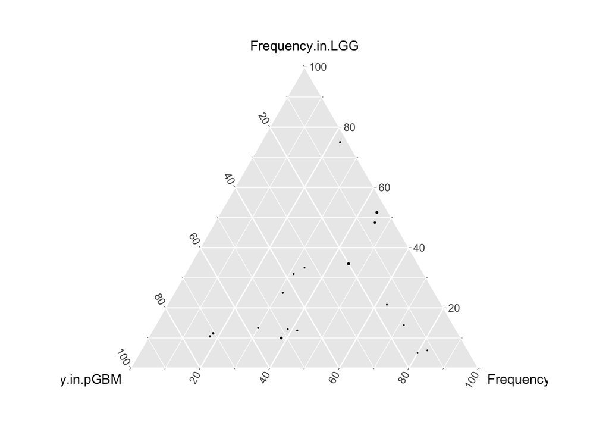

```r
# 使用安装的 ggtern 包时，size 应该作为 geom_point() 的参数，而不是在 aes() 中
# When using installed ggtern package, size should be a parameter of geom_point(), not in aes()
ggtern(data=df, aes(x=Frequency.in.pGBM,
                    y=Frequency.in.LGG,
                    z=Frequency.in.sGBM)) +
   geom_point(size = df$Alteration.Frequency.in.glioma)
```

可以看到，点的大小和原文有较大出入，说明原文对数据进行了一定的优化。

As you can see, the dot sizes are quite different from the original article, indicating that the original article has optimized the data in some way.

## 7 把size扩大50倍 Increase the size by 50 times

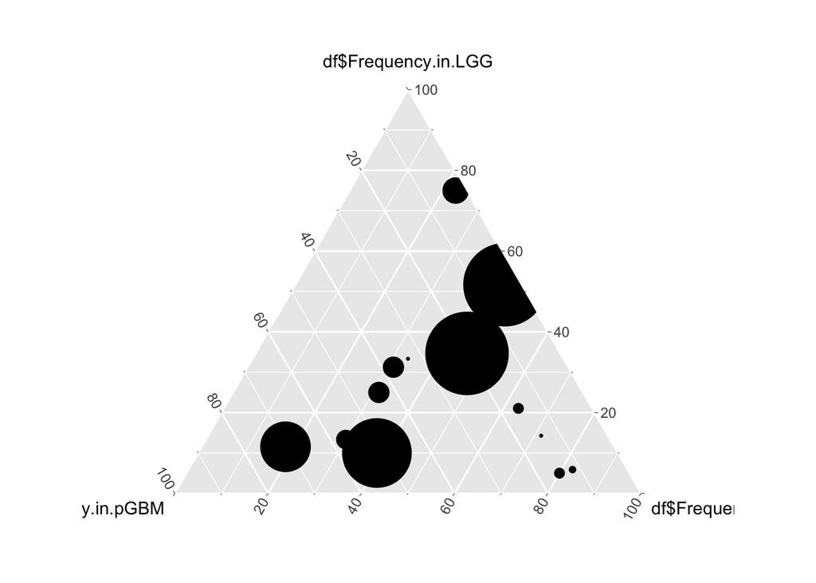

```r
ggtern(data=df,aes(x=df$Frequency.in.pGBM,y=df$Frequency.in.LGG,z=df$Frequency.in.sGBM)) +
   geom_point(size=df$Alteration.Frequency.in.glioma*50)
```

可以看到，除了几个较大的点，其他点大小同原文相似度极高，估计作者对特大值进行了不同的处理

As you can see, except for a few larger dots, the size of other dots is very similar to the original text, and it is assumed that the author handled the extremely large values differently

## 8 分段处理 Segmented processing

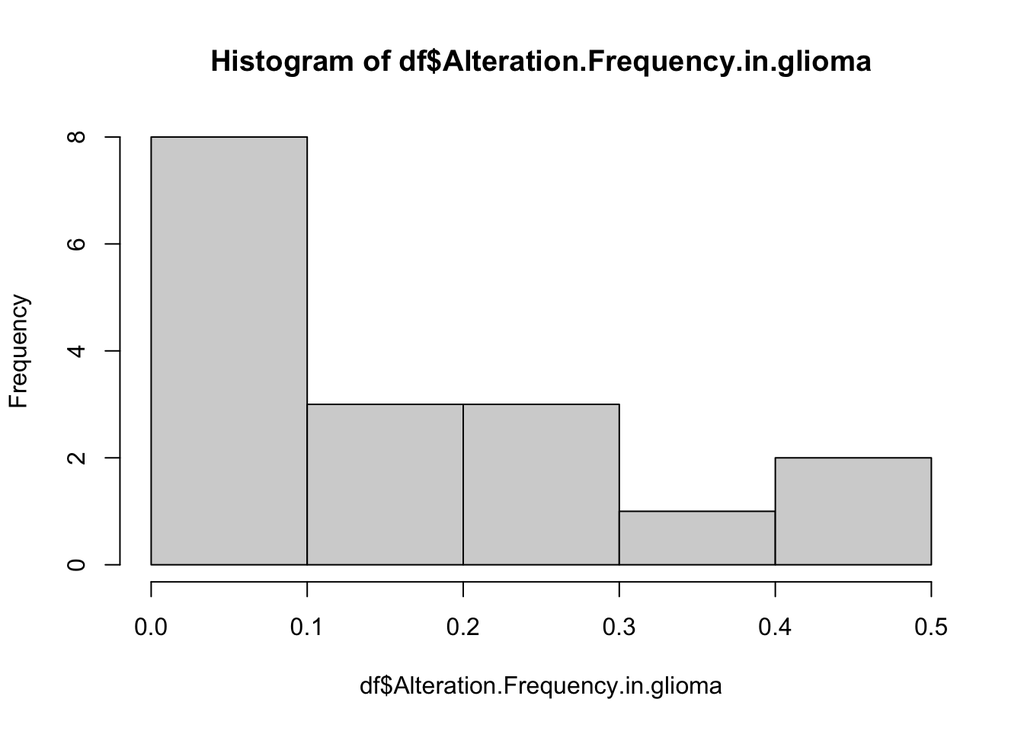

```r
#先查看分布
#view the distribution first
hist(df$Alteration.Frequency.in.glioma)
```

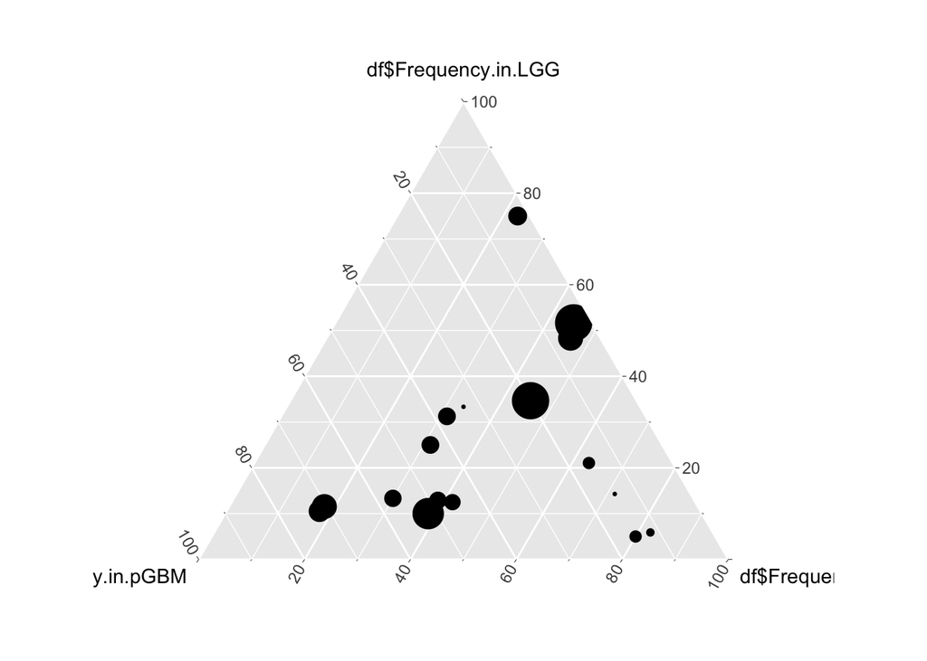

```r
#用0.1作为阈值来分段
#segment using 0.1 as a threshold
df$allfrequency <- ifelse(df$Alteration.Frequency.in.glioma >= 0.1,
                       10^(df$Alteration.Frequency.in.glioma) * 3,
                       50 * (df$Alteration.Frequency.in.glioma))

ggtern(data=df, aes(x=df$Frequency.in.pGBM,
                    y=df$Frequency.in.LGG,
                    z=df$Frequency.in.sGBM)) +
   geom_point(size=df$allfrequency)
```

```r
write.csv(df[,c(1,4,8,11,13)],"easy_input.csv", quote = F, row.names = F)
```

接下来就采用这种方式预处理输入数据，调整细节、美化图形。

Next, use this method to preprocess the input data, adjust the details, and beautify the graphics.

## 9 输入文件 Input file

easy_input.csv：包含5列。

- 第1列，基因名；
- 第2、3、4列，对应xyz坐标。此处代表基因在GBM各亚型中的突变频率；
- 第5列，点的大小。此处代表基因在所有GBM中总的突变频率。

至少包含3列，即3个坐标：x，y，z，即可画出点在三角形的位置。

点的大小和颜色可以按照自己的生物学意义处理。

easy_input.csv: contains 5 columns.

- Column 1, gene name;
- Columns 2, 3 and 4, corresponding to xyz coordinates. This represents the mutation frequency of the gene in each subtype of GBM;
- Column 5, dot size. This represents the total mutation frequency of the gene in all GBMs.

At least 3 columns, namely 3 coordinates: x, y, z, and the position of the dot in the triangle can be drawn.

The size and color of the dots can be treated according to their biological significance.

```r
df <- read.csv('easy_input.csv')
head(df)
```

```
##            Gene Frequency.in.sGBM Frequency.in.pGBM Frequency.in.LGG
## 1       METex14              0.14              0.02             0.01
## 2 Hypermutation              0.16              0.03             0.01
## 3            ZM              0.05              0.01             0.01
## 4 MET Amplified              0.12              0.03             0.04
## 5          ATRX              0.41              0.05             0.43
## 6          TP53              0.68              0.30             0.52
##   allfrequency
## 1     1.500000
## 2     2.500000
## 3     0.500000
## 4     2.500000
## 5     5.716382
## 6     8.853628
```

## 10 开始画图 Start drawing

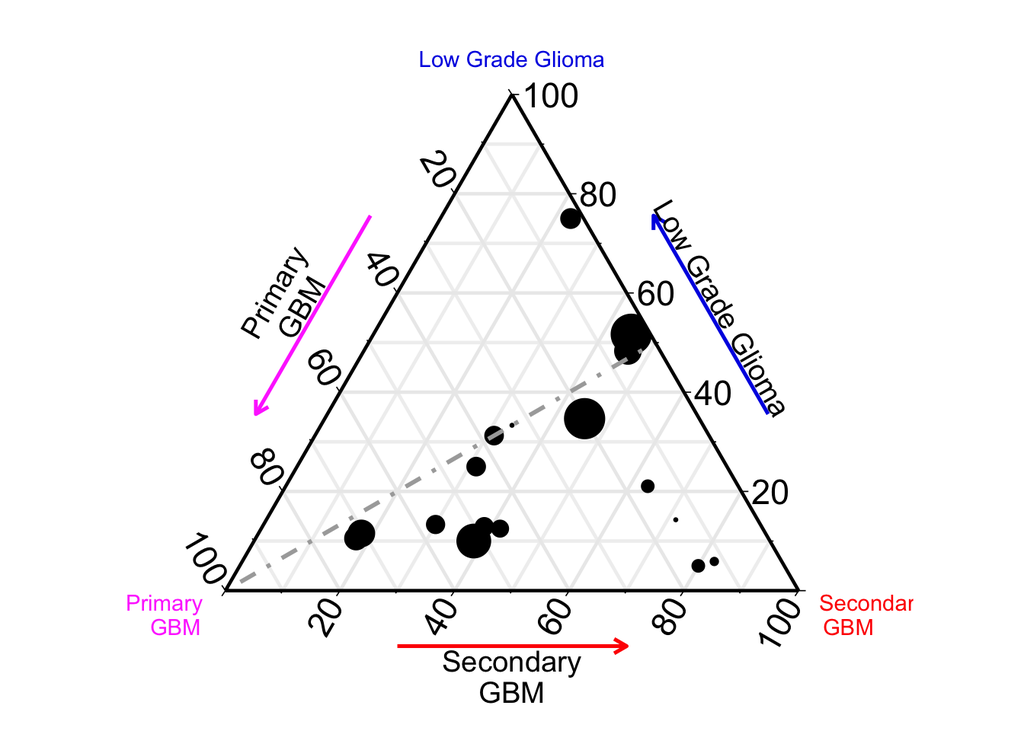

```r
p <- ggtern(data=df, aes(x=df$Frequency.in.pGBM, y=df$Frequency.in.LGG, z=df$Frequency.in.sGBM)) +
  geom_point(size = df$allfrequency) + #用allfrequency来定义点的大小 define the dot size with allfrequency
  theme_custom(18, '') + #字体大小 font size
  labs(x='Primary\nGBM', z='Secondary\nGBM', y='Low Grade Glioma')+ #加label add label
  theme(tern.panel.background = element_rect(fill = "white"), #背景白色 white background
                                            tern.panel.grid.minor = element_line(color = "gray90"), #背景网格颜色 background grid color
                                            tern.axis.arrow.show = TRUE, #画箭头 draw arrows

        #箭头颜色和大小 L: LEFT, R: RIGHT, T: TOP
        #arrow color and size L: LEFT, R: RIGHT, T: TOP
        tern.axis.arrow.T = element_line(color ='#0000E3', size = 2.5),
        tern.axis.arrow.L = element_line(color = '#FF44FF', size = 2.5),
        tern.axis.arrow.R = element_line(color = 'red', size = 2.5),

        #箭头上字的颜色
        #color of the text on the arrow
        tern.axis.arrow.text.L = element_text(color = 'black'),
        tern.axis.arrow.text.T = element_text(color = 'black'),
        tern.axis.arrow.text.R = element_text(color = 'black'),

        #箭头距离三角形的远近
        #the distance from the arrow to the triangle
        tern.axis.arrow.sep = 0.1,

        #背景网格颜色、线型、粗细
        #background grid color, line type, thickness
        tern.panel.grid.major.T = element_line(color = 'gray92', linetype = 1, size = 0.8),
        tern.panel.grid.major.L = element_line(color = 'gray92', linetype = 1, size = 0.8),
        tern.panel.grid.major.R = element_line(color = 'gray92', linetype = 1, size = 0.8),
        tern.panel.grid.minor.T = element_line(color = 'gray94', linetype = 1, size = 0.8),
        tern.panel.grid.minor.L = element_line(color = 'gray94', linetype = 1, size = 0.8),
        tern.panel.grid.minor.R = element_line(color = 'gray94', linetype = 1, size = 0.8),

        #坐标轴title的字体颜色、大小
        #font color and size of the axis title
        tern.axis.title.L = element_text(color = '#FF44FF', size = 11),
        tern.axis.title.T = element_text(color = '#0000E3', size = 11),
        tern.axis.title.R = element_text(color = 'red', size = 11),

        #坐标轴标签的字号
        #font size of axis labels
        tern.axis.text.L = element_text(size = 17,face = 'bold'),
        tern.axis.text.R = element_text(size = 17,face = 'bold'),
        tern.axis.text.T = element_text(size = 17,face = 'bold'),

        #整体画布往上移动一点，避免压到字
        #move the overall canvas up a bit to avoid overlapping with the text
        tern.axis.vshift = 0.04,

        #坐标轴粗细
        #axis thickness
        tern.axis.line.T = element_line(size = 0.8),
        tern.axis.line.R = element_line(size = 0.8),
        tern.axis.line.L = element_line(size = 0.8)) +

  #画一条虚线
  #draw a dashed line
  geom_Lisoprop(color='darkgrey', value=.5, linetype=4, size=1)
p
```

## 11 给点加颜色 Add color to dots

在原文中，颜色代表相对的表达频率，那么有3个类型，要上3种颜色，怎么办？

此处采用逐层上颜色，同时设置为半透明：

突变频率越高，则堆砌的颜色则越深，越有意义。

In the original text, color represents relative expression frequency, so there are 3 types, requiring 3 colors, what should be done?

Here, we apply colors layer by layer, while setting them to be semi-transparent:

The higher the mutation frequency, the deeper the stacked color, and the more significant it is.

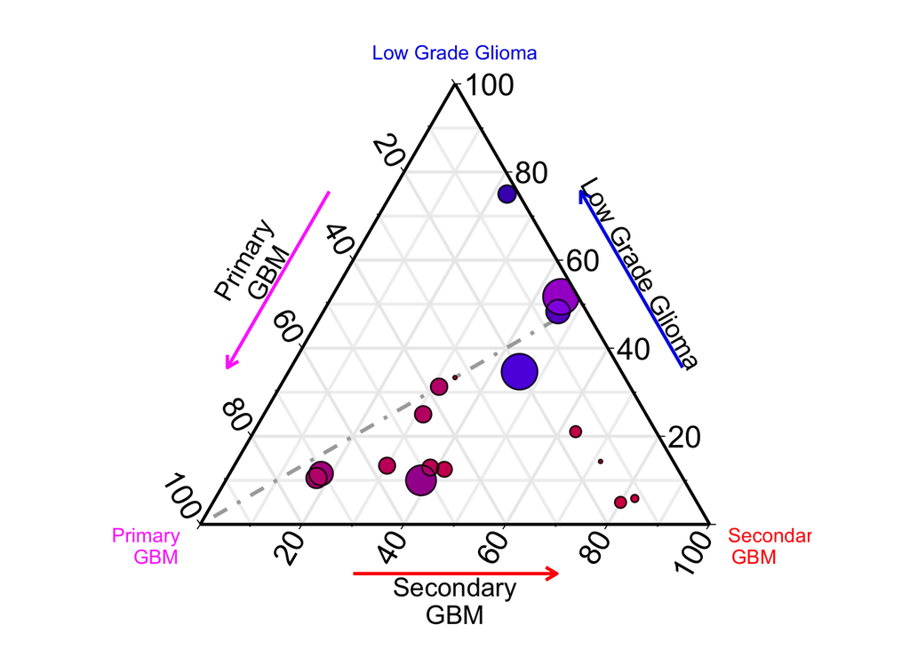

```r
p1 <- p +
  #分别画三种亚型的突变频率，图层叠加
  #draw the mutation frequency of three subtypes respectively, with layered overlay
  geom_point(aes(color=df$Frequency.in.sGBM), size=df$allfrequency, alpha=0.7) + #半透明 semi-transparent
  geom_point(aes(color=df$Frequency.in.pGBM), size=df$allfrequency, alpha=0.7) +
  geom_point(aes(color=df$Frequency.in.LGG), size=df$allfrequency, alpha=0.7) +
  scale_color_gradient2(low='red', mid = '#0000E3', high ='purple', midpoint = 0.33, #三种颜色 three colors
                        guide = FALSE) + #不画图例 do not draw legend

  #每个圈圈外面加个黑圈
  #add a black circle to each circle
  geom_point(size=df$allfrequency, shape = 1, alpha = 0.8,
             stroke = 0.7, #线的粗细 thickness of the line
             color = "black")
p1
```

```r
#保存到pdf文件
#save to PDF file
ggsave("triangle.pdf")
```

## 12 标基因名 Label gene names

为了避免基因名的重叠，我们通常会使用ggrepel，可惜ggrepel不支持ggtern。另外，geom_text的check_overlap也对ggtern无效。提供以下两种方案来解决字的重叠问题：

To avoid overlapping of gene names, we usually use ggrepel, but unfortunately ggrepel does not support ggtern. Additionally, check_overlap of geom_text does not work for ggtern. The following two plans are provided to solve the word overlap problem:

### 12.1 方案一：geom_text + AI Plan 1: geom_text + AI

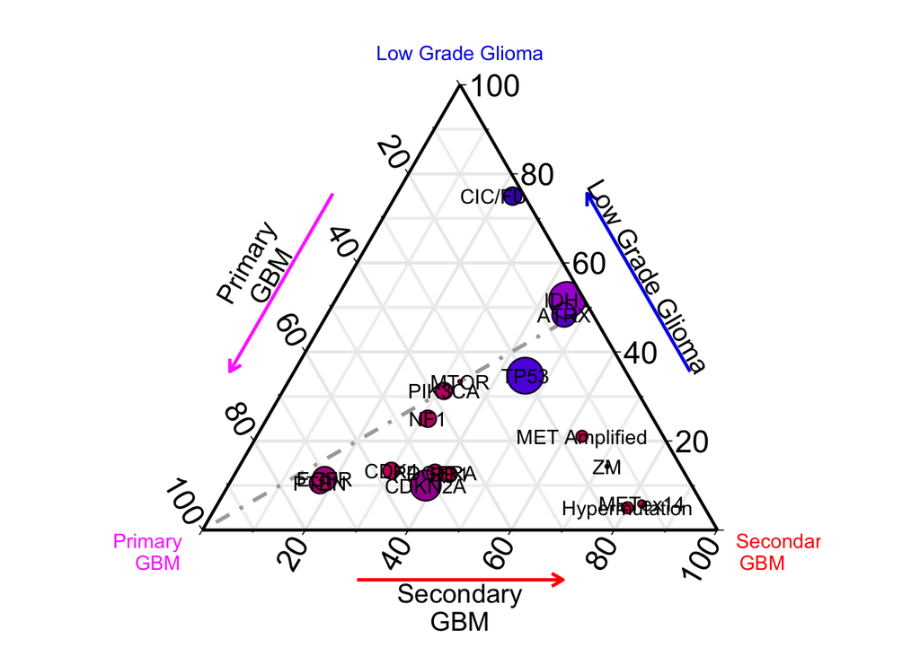

```r
p1 + geom_text(aes(label=Gene))
```

```r
ggsave('triangle_geom_text.pdf')
```

优点：能标出全部基因名

缺点：需要用Illustrator打开pdf文件，然后用鼠标拖动基因名来微调。

Advantage: label all gene names

Disadvantage: need to open the pdf file with Illustrator and then drag the gene names with the mouse to fine-tune.

### 12.2 方案二：用directlabels包 Plan 2: Use the directlabels package

参考这篇：https://mp.weixin.qq.com/s/6MMVsO22n9oKZNC7qC7g5A

Refer to this article: https://mp.weixin.qq.com/s/6MMVsO22n9oKZNC7qC7g5A

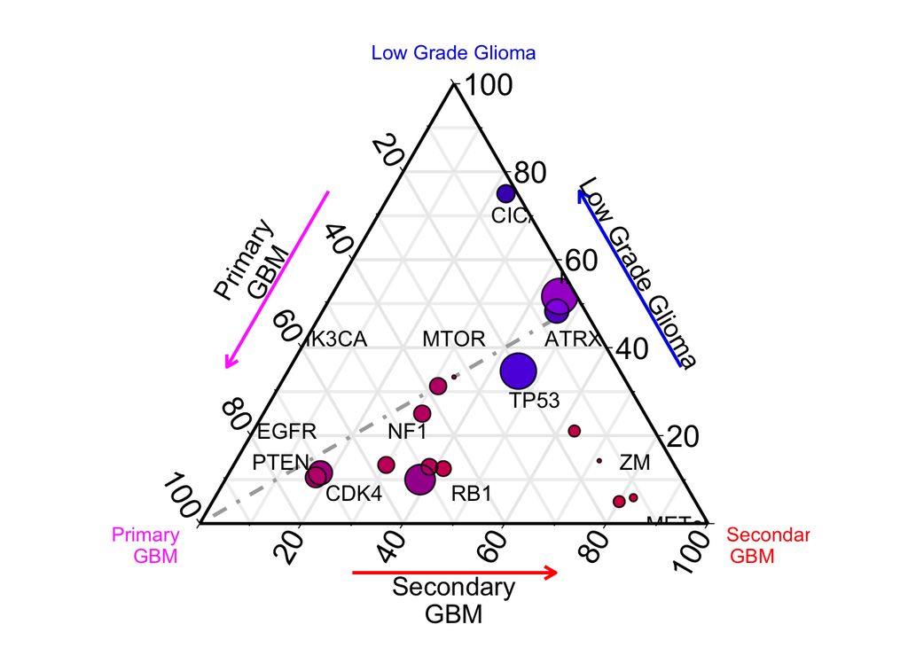

```r
p1 + geom_dl(aes(label=Gene), method = "smart.grid")
```

```r
ggsave('triangle_directlabels.pdf')
```

优点：大部分基因名分散较好

缺点：包里的参数有限。基因名离基因较远，需要参照方案一核对基因跟点的对应关系。另外，边缘的基因名溢出。因此，需要借用Illustrator微调。

Advantage: Most gene names are well dispersed.

Disadvantage: The parameters in the package are limited. Gene names are far from the genes, requiring referring to Plan 1 to verify the correspondence between genes and dots. Additionally, gene names at the edges overflow. Therefore, it is necessary to use Illustrator for fine-tuning.